# STAT545 Assignment 4

Harper Cheng

10/2/2019

Load libraries and dataset

```r
library(gapminder)
library(dplyr)
library(tidyr)
library(ggplot2)
library(readr)
```

# Exercise 1: Univariate Data Reshaping

## Univariate Option 1

### 1.1 Reshaping

Make a tibble with one row per year, and columns for life expectancy for two or more countries.

```r
dat1 <- gapminder %>%
  pivot_wider(id_cols=year,
              names_from=country,
              values_from=lifeExp)
dat1 %>% DT::datatable()
```

|  | year | Afghanistan | Albania | Algeria | Angola | Argentina | Australia | Austria | Bahrain | Bangladesh | Belgium | Benin | Bolivia | Bosnia and Herzegovina | Botswana | Brazil | Bulgaria | Burkina Faso | Burundi | Cambodia | Cameroon | Canada | Central African Republic | Chad | Chile | China | Colombia | Comoros | Congo, Dem. Rep. | … |
| --- | --- | --- | --- | --- | --- | --- | --- | --- | --- | --- | --- | --- | --- | --- | --- | --- | --- | --- | --- | --- | --- | --- | --- | --- | --- | --- | --- | --- | --- | --- |
| 1 | 1952 | 28.801 | 55.23 | 43.077 | 30.015 | 62.485 | 69.12 | 66.8 | 50.939 | 37.484 | 68 | 38.223 | 40.414 | 53.82 | 47.622 | 50.917 | 59.6 | 31.975 | 39.031 | 39.417 | 38.523 | 68.75 | 35.463 | 38.092 | 54.745 | 44 | 50.643 | 40.715 | 39.143 | … |
| 2 | 1957 | 30.332 | 59.28 | 45.685 | 31.999 | 64.399 | 70.33 | 67.48 | 53.832 | 39.348 | 69.24 | 40.358 | 41.89 | 58.45 | 49.618 | 53.285 | 66.61 | 34.906 | 40.533 | 41.366 | 40.428 | 69.96 | 37.464 | 39.881 | 56.074 | 50.54896 | 55.118 | 42.46 | 40.652 | … |
| 3 | 1962 | 31.997 | 64.82 | 48.303 | 34 | 65.142 | 70.93 | 69.54 | 56.923 | 41.216 | 70.25 | 42.618 | 43.428 | 61.93 | 51.52 | 55.665 | 69.51 | 37.814 | 42.045 | 43.415 | 42.643 | 71.3 | 39.475 | 41.716 | 57.924 | 44.50136 | 57.863 | 44.467 | 42.122 | … |
| 4 | 1967 | 34.02 | 66.22 | 51.407 | 35.985 | 65.634 | 71.1 | 70.14 | 59.923 | 43.453 | 70.94 | 44.885 | 45.032 | 64.79 | 53.298 | 57.632 | 70.42 | 40.697 | 43.548 | 45.415 | 44.799 | 72.13 | 41.478 | 43.601 | 60.523 | 58.38112 | 59.963 | 46.472 | 44.056 | … |
| 5 | 1972 | 36.088 | 67.69 | 54.518 | 37.928 | 67.065 | 71.93 | 70.63 | 63.3 | 45.252 | 71.44 | 47.014 | 46.714 | 67.45 | 56.024 | 59.504 | 70.9 | 43.591 | 44.057 | 40.317 | 47.049 | 72.88 | 43.457 | 45.569 | 63.441 | 63.11888 | 61.623 | 48.944 | 45.989 | … |
| 6 | 1977 | 38.438 | 68.93 | 58.014 | 39.483 | 68.481 | 73.49 | 72.17 | 65.593 | 46.923 | 72.8 | 49.19 | 50.023 | 69.86 | 59.319 | 61.489 | 70.81 | 46.137 | 45.91 | 31.22 | 49.355 | 74.21 | 46.775 | 47.383 | 67.052 | 63.96736 | 63.837 | 50.939 | 47.804 | … |
| 7 | 1982 | 39.854 | 70.42 | 61.368 | 39.942 | 69.942 | 74.74 | 73.18 | 69.052 | 50.009 | 73.93 | 50.904 | 53.859 | 70.69 | 61.484 | 63.336 | 71.08 | 48.122 | 47.471 | 50.957 | 52.961 | 75.76 | 48.295 | 49.517 | 70.565 | 65.525 | 66.653 | 52.933 | 47.784 | … |
| 8 | 1987 | 40.822 | 72 | 65.799 | 39.906 | 70.774 | 76.32 | 74.94 | 70.75 | 52.819 | 75.35 | 52.337 | 57.251 | 71.14 | 63.622 | 65.205 | 71.34 | 49.557 | 48.211 | 53.914 | 54.985 | 76.86 | 50.485 | 51.051 | 72.492 | 67.274 | 67.768 | 54.926 | 47.412 | … |
| 9 | 1992 | 41.674 | 71.581 | 67.744 | 40.647 | 71.868 | 77.56 | 76.04 | 72.601 | 56.018 | 76.46 | 53.919 | 59.957 | 72.178 | 62.745 | 67.057 | 71.19 | 50.26 | 44.736 | 55.803 | 54.314 | 77.95 | 49.396 | 51.724 | 74.126 | 68.69 | 68.421 | 57.939 | 45.548 | … |
| 10 | 1997 | 41.763 | 72.95 | 69.152 | 40.963 | 73.275 | 78.83 | 77.51 | 73.925 | 59.412 | 77.53 | 54.777 | 62.05 | 73.244 | 52.556 | 69.388 | 70.32 | 50.324 | 45.326 | 56.534 | 52.199 | 78.61 | 46.066 | 51.573 | 75.816 | 70.426 | 70.313 | 60.66 | 42.587 | … |

[output cut: 2 more lines]

### 1.2 ggplot

Take advantage of this new data shape to scatterplot life expectancy for one country against that of another.

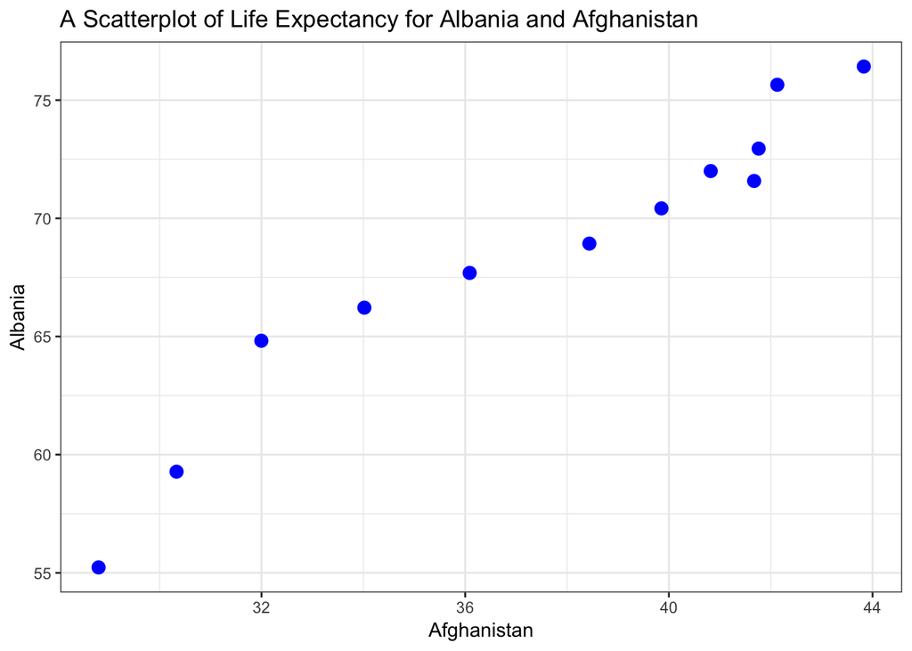

```r
dat1 %>%
  ggplot(aes(x=Afghanistan, y=Albania)) +
  geom_point(size=3, color='blue') +
  labs(title='A Scatterplot of Life Expectancy for Albania and Afghanistan') +
  theme_bw()
```

### 1.3 Re-lengthening

Re-lengthen the data.

```r
dat1 %>%
  pivot_longer(cols=-year,
               names_to="country",
               values_to="lifeExp") %>%
  arrange(country) %>%
  DT::datatable()
```

|  | year | country | lifeExp |
| --- | --- | --- | --- |
| 1 | 1952 | Afghanistan | 28.801 |
| 2 | 1957 | Afghanistan | 30.332 |
| 3 | 1962 | Afghanistan | 31.997 |
| 4 | 1967 | Afghanistan | 34.02 |
| 5 | 1972 | Afghanistan | 36.088 |
| 6 | 1977 | Afghanistan | 38.438 |
| 7 | 1982 | Afghanistan | 39.854 |
| 8 | 1987 | Afghanistan | 40.822 |
| 9 | 1992 | Afghanistan | 41.674 |
| 10 | 1997 | Afghanistan | 41.763 |

[output cut: 1694 more lines]

# Exercise 2: Multivariate Data Reshaping

## Multivariate Option 1

### 2.1 Reshaping

Make a tibble with one row per year, and columns for life expectancy and GDP per capita for two or more countries.

```r
dat2 <- gapminder %>%
  filter(country %in% c("Afghanistan", "Albania")) %>%
  pivot_wider(id_cols=year,
              names_from=country,
              names_sep="_",
              values_from=c(lifeExp, gdpPercap))
dat2 %>% DT::datatable()
```

|  | year | lifeExp_Afghanistan | lifeExp_Albania | gdpPercap_Afghanistan | gdpPercap_Albania |
| --- | --- | --- | --- | --- | --- |
| 1 | 1952 | 28.801 | 55.23 | 779.4453145 | 1601.056136 |
| 2 | 1957 | 30.332 | 59.28 | 820.8530296 | 1942.284244 |
| 3 | 1962 | 31.997 | 64.82 | 853.10071 | 2312.888958 |
| 4 | 1967 | 34.02 | 66.22 | 836.1971382 | 2760.196931 |
| 5 | 1972 | 36.088 | 67.69 | 739.9811058 | 3313.422188 |
| 6 | 1977 | 38.438 | 68.93 | 786.11336 | 3533.00391 |
| 7 | 1982 | 39.854 | 70.42 | 978.0114388 | 3630.880722 |
| 8 | 1987 | 40.822 | 72 | 852.3959448 | 3738.932735 |
| 9 | 1992 | 41.674 | 71.581 | 649.3413952 | 2497.437901 |
| 10 | 1997 | 41.763 | 72.95 | 635.341351 | 3193.054604 |

[output cut: 2 more lines]

### 2.2 Re-lengthening

Re-lengthen the data.

```r
dat2 %>%
  pivot_longer(cols=-year,
               names_to=c(".value", "country"),
               names_sep="_") %>%
  DT::datatable()
```

|  | year | country | lifeExp | gdpPercap |
| --- | --- | --- | --- | --- |
| 1 | 1952 | Afghanistan | 28.801 | 779.4453145 |
| 2 | 1952 | Albania | 55.23 | 1601.056136 |
| 3 | 1957 | Afghanistan | 30.332 | 820.8530296 |
| 4 | 1957 | Albania | 59.28 | 1942.284244 |
| 5 | 1962 | Afghanistan | 31.997 | 853.10071 |
| 6 | 1962 | Albania | 64.82 | 2312.888958 |
| 7 | 1967 | Afghanistan | 34.02 | 836.1971382 |
| 8 | 1967 | Albania | 66.22 | 2760.196931 |
| 9 | 1972 | Afghanistan | 36.088 | 739.9811058 |
| 10 | 1972 | Albania | 67.69 | 3313.422188 |

[output cut: 14 more lines]

# Exercise 3: Table Joins

## 3.1

For each guest in the guestlist (`guest` tibble), add a column for email address, which can be found in the `email` tibble.

```r
email_list <- email%>%
  separate_rows(guest, sep=", ") %>%
  rename(name=guest)

guest %>%
  left_join(email_list, by="name") %>%
  DT::datatable()
```

|  | party | name | meal_wedding | meal_brunch | attendance_wedding | attendance_brunch | attendance_golf | email |
| --- | --- | --- | --- | --- | --- | --- | --- | --- |
| 1 | 1 | Sommer Medrano | PENDING | PENDING | PENDING | PENDING | PENDING | sommm@gmail.com |
| 2 | 1 | Phillip Medrano | vegetarian | Menu C | CONFIRMED | CONFIRMED | CONFIRMED | sommm@gmail.com |
| 3 | 1 | Blanka Medrano | chicken | Menu A | CONFIRMED | CONFIRMED | CONFIRMED | sommm@gmail.com |
| 4 | 1 | Emaan Medrano | PENDING | PENDING | PENDING | PENDING | PENDING | sommm@gmail.com |
| 5 | 2 | Blair Park | chicken | Menu C | CONFIRMED | CONFIRMED | CONFIRMED | bpark@gmail.com |
| 6 | 2 | Nigel Webb |  |  | CANCELLED | CANCELLED | CANCELLED | bpark@gmail.com |
| 7 | 3 | Sinead English | PENDING | PENDING | PENDING | PENDING | PENDING | singlish@hotmail.ca |
| 8 | 4 | Ayra Marks | vegetarian | Menu B | PENDING | PENDING | PENDING | marksa42@gmail.com |
| 9 | 5 | Atlanta Connolly | PENDING | PENDING | PENDING | PENDING | PENDING |  |
| 10 | 5 | Denzel Connolly | fish | Menu B | CONFIRMED | CONFIRMED | CONFIRMED |  |

[output cut: 20 more lines]

## 3.2

Who do we have emails for, yet are not on the guestlist?

```r
email_list %>%
  anti_join(guest, by="name") %>%
  DT::datatable()
```

|  | name | email |
| --- | --- | --- |
| 1 | Turner Jones | tjjones12@hotmail.ca |
| 2 | Albert Marshall | themarshallfamily1234@gmail.com |
| 3 | Vivian Marshall | themarshallfamily1234@gmail.com |

## 3.3

Make a guestlist that includes everyone we have emails for (in addition to those on the original guestlist).

```r
email_list %>%
  full_join(guest, by="name") %>%
  DT::datatable()
```

|  | name | email | party | meal_wedding | meal_brunch | attendance_wedding | attendance_brunch | attendance_golf |
| --- | --- | --- | --- | --- | --- | --- | --- | --- |
| 1 | Sommer Medrano | sommm@gmail.com | 1 | PENDING | PENDING | PENDING | PENDING | PENDING |
| 2 | Phillip Medrano | sommm@gmail.com | 1 | vegetarian | Menu C | CONFIRMED | CONFIRMED | CONFIRMED |
| 3 | Blanka Medrano | sommm@gmail.com | 1 | chicken | Menu A | CONFIRMED | CONFIRMED | CONFIRMED |
| 4 | Emaan Medrano | sommm@gmail.com | 1 | PENDING | PENDING | PENDING | PENDING | PENDING |
| 5 | Blair Park | bpark@gmail.com | 2 | chicken | Menu C | CONFIRMED | CONFIRMED | CONFIRMED |
| 6 | Nigel Webb | bpark@gmail.com | 2 |  |  | CANCELLED | CANCELLED | CANCELLED |
| 7 | Sinead English | singlish@hotmail.ca | 3 | PENDING | PENDING | PENDING | PENDING | PENDING |
| 8 | Ayra Marks | marksa42@gmail.com | 4 | vegetarian | Menu B | PENDING | PENDING | PENDING |
| 9 | Jolene Welsh | jw1987@hotmail.com | 6 |  |  | CANCELLED | CANCELLED | CANCELLED |
| 10 | Hayley Booker | jw1987@hotmail.com | 6 | vegetarian | Menu C | CONFIRMED | CONFIRMED | CONFIRMED |

[output cut: 23 more lines]